# Medicare Skilled Nursing Facility utilization and payment data (2019–2023)

Melissa Chhay

2026-06-03

# Data Loading & QC

```r
# Load 2023 data
raw_data_2023 <- read_csv("data/PACU_2023.csv") |> clean_names()
# QC: raw dimensions
cat("Raw row count:", nrow(raw_data_2023), "\n")
```

```
## Raw row count: 14214
```

```r
cat("Columns:", ncol(raw_data_2023), "\n")
```

```
## Columns: 69
```

```r
# QC: SMRY_CTGRY breakdown
cat("SMRY_CTGRY values:\n")
```

```
## SMRY_CTGRY values:
```

```r
print(table(raw_data_2023$smry_ctgry, useNA = "always"))
```

```
##
##   NATION PROVIDER    STATE     <NA>
##        1    14161       52        0
```

```r
# Filter to PROVIDER rows ONLY
provider_2023 <- raw_data_2023 |> filter(smry_ctgry == "PROVIDER")

cat("Provider rows after filter:", nrow(provider_2023), "\n")
```

```
## Provider rows after filter: 14161
```

```r
# QC: duplicate PRVDR_IDs
dup_check <- provider_2023 |> count(prvdr_id) |> filter(n > 1)
cat("Duplicate PRVDR_IDs:", nrow(dup_check), "\n")
```

```
## Duplicate PRVDR_IDs: 0
```

```r
# QC: missingness in payment column
cat("Missing TOT_MDCR_STDZD_PYMT_AMT:", sum(is.na(provider_2023$tot_mdcr_stdzd_pymt_amt)), "\n")
```

```
## Missing TOT_MDCR_STDZD_PYMT_AMT: 0
```

```r
# QC: check for suppressed/non-numeric values
# (CMS suppresses small cells with "*"; coercing to numeric turns those to NA)
cat("Rows with non-numeric payment (suppressed):",
    sum(is.na(as.numeric(provider_2023$tot_mdcr_stdzd_pymt_amt))), "\n")
```

```
## Rows with non-numeric payment (suppressed): 0
```

```r
# QC: confirm bene_dual_pct scale
cat("bene_dual_pct range:", range(provider_2023$bene_dual_pct, na.rm = TRUE), "\n")
```

```
## bene_dual_pct range: * 98
```

# Part 1: Quantitative Analysis of 2023 Data

## Summary Statistics

```r
payment_stats <- provider_2023 |>
  summarise(
    n       = n(),
    mean    = round(mean(tot_mdcr_stdzd_pymt_amt,                    na.rm = TRUE), 2),
    sd      = round(sd(tot_mdcr_stdzd_pymt_amt,                      na.rm = TRUE), 2),
    min     = round(min(tot_mdcr_stdzd_pymt_amt,                      na.rm = TRUE), 2),
    p25     = round(quantile(tot_mdcr_stdzd_pymt_amt, 0.25,           na.rm = TRUE), 2),
    median  = round(median(tot_mdcr_stdzd_pymt_amt,                   na.rm = TRUE), 2),
    p75     = round(quantile(tot_mdcr_stdzd_pymt_amt, 0.75,           na.rm = TRUE), 2),
    max     = round(max(tot_mdcr_stdzd_pymt_amt,                      na.rm = TRUE), 2)
  )

kable(payment_stats,
      caption = "Summary Statistics: TOT_MDCR_STDZD_PYMT_AMT (2023, Provider rows)",
      format.args = list(big.mark = ",")) |>
  kable_styling(bootstrap_options = c("striped", "hover"), full_width = FALSE)
```

Summary Statistics: TOT_MDCR_STDZD_PYMT_AMT (2023, Provider rows)

| n | mean | sd | min | p25 | median | p75 | max |
| --- | --- | --- | --- | --- | --- | --- | --- |
| 14,161 | 1,846,518 | 1,925,772 | 29,875 | 679,251 | 1,257,114 | 2,316,166 | 34,389,366 |

## Top 5 and Bottom 5 States by Mean Standardized Payment

```r
state_means <- provider_2023 |> group_by(state) |>
  summarise(
    n_providers  = n(),
    mean_payment = round(mean(tot_mdcr_stdzd_pymt_amt, na.rm = TRUE), 2)
  ) |>
  arrange(mean_payment)

bottom_5 <- head(state_means, 5) |> arrange(desc(mean_payment))
top_5    <- tail(state_means, 5) |> arrange(desc(mean_payment))

kable(bottom_5,
      caption = "Bottom 5 States by Mean TOT_MDCR_STDZD_PYMT_AMT",
      format.args = list(big.mark = ",")) |>
  kable_styling(bootstrap_options = c("striped", "hover"), full_width = FALSE)
```

Bottom 5 States by Mean TOT_MDCR_STDZD_PYMT_AMT

| state | n_providers | mean_payment |
| --- | --- | --- |
| ME | 78 | 985,063.4 |
| ND | 59 | 979,802.8 |
| MN | 301 | 934,097.2 |
| IA | 375 | 680,791.4 |
| PR | 5 | 168,741.0 |

```r
kable(top_5,
      caption = "Top 5 States by Mean TOT_MDCR_STDZD_PYMT_AMT",
      format.args = list(big.mark = ",")) |>
  kable_styling(bootstrap_options = c("striped", "hover"), full_width = FALSE)
```

Top 5 States by Mean TOT_MDCR_STDZD_PYMT_AMT

| state | n_providers | mean_payment |
| --- | --- | --- |
| NY | 590 | 4,468,203 |
| NJ | 340 | 3,651,967 |
| MD | 218 | 3,472,437 |
| FL | 692 | 3,120,983 |
| NV | 54 | 3,120,511 |

## Dual-Eligible Comparison

```r
# bene_dual_pct is on a 0–100 scale; threshold is >= 50 (i.e., 50% or more dual)
dual_comparison <- provider_2023 |>
  mutate(dual_group = if_else(bene_dual_pct >= 50, ">=50% dual", "<50% dual")) |>
  group_by(dual_group) |>
  summarise(
    n            = n(),
    mean_payment = round(mean(tot_mdcr_stdzd_pymt_amt, na.rm = TRUE), 2)
  )

kable(dual_comparison,
      caption = "Mean TOT_MDCR_STDZD_PYMT_AMT by Dual-Eligible Share (2023)",
      format.args = list(big.mark = ",")) |>
  kable_styling(bootstrap_options = c("striped", "hover"), full_width = FALSE)
```

Mean TOT_MDCR_STDZD_PYMT_AMT by Dual-Eligible Share (2023)

| dual_group | n | mean_payment |
| --- | --- | --- |
| <50% dual | 10,141 | 1,738,991 |
| >=50% dual | 4,020 | 2,117,769 |

# Part 2: Longitudinal Trend (2019–2023)

```r
# Load all five years, filter to PROVIDER rows, tag with year
years   <- 2019:2023
snf_all <- map_dfr(years, function(yr) {
  read_csv(glue("data/PACU_{yr}.csv"), show_col_types = FALSE) |>
    clean_names() |>
    filter(smry_ctgry == "PROVIDER") |>
    mutate(year = yr)
})

# QC: row counts per year before sample restriction
cat("Row counts by year (all providers):\n")
```

```
## Row counts by year (all providers):
```

```r
print(count(snf_all, year))
```

```
## # A tibble: 5 × 2
##    year     n
##   <int> <int>
## 1  2019 14820
## 2  2020 14618
## 3  2021 14559
## 4  2022 14387
## 5  2023 14161
```

```r
# QC: unique providers per year
providers_per_year <- snf_all |>
  group_by(year) |>
  summarise(unique_providers = n_distinct(prvdr_id))

print(providers_per_year)
```

```
## # A tibble: 5 × 2
##    year unique_providers
##   <int>            <int>
## 1  2019            14820
## 2  2020            14618
## 3  2021            14559
## 4  2022            14387
## 5  2023            14161
```

```r
# Identify providers present in all 5 years
ids_all_years <- snf_all |>
  group_by(prvdr_id) |>
  summarise(n_years = n_distinct(year)) |>
  filter(n_years == 5) |>
  pull(prvdr_id)

cat("Providers present in all 5 years:", length(ids_all_years), "\n")
```

```
## Providers present in all 5 years: 13497
```

```r
# Restrict to balanced panel
snf_balanced <- snf_all |>
  filter(prvdr_id %in% ids_all_years)

# QC: confirm each year has the same N
cat("Row counts by year (balanced panel):\n")
```

```
## Row counts by year (balanced panel):
```

```r
print(count(snf_balanced, year))
```

```
## # A tibble: 5 × 2
##    year     n
##   <int> <int>
## 1  2019 13497
## 2  2020 13497
## 3  2021 13497
## 4  2022 13497
## 5  2023 13497
```

## Visualization

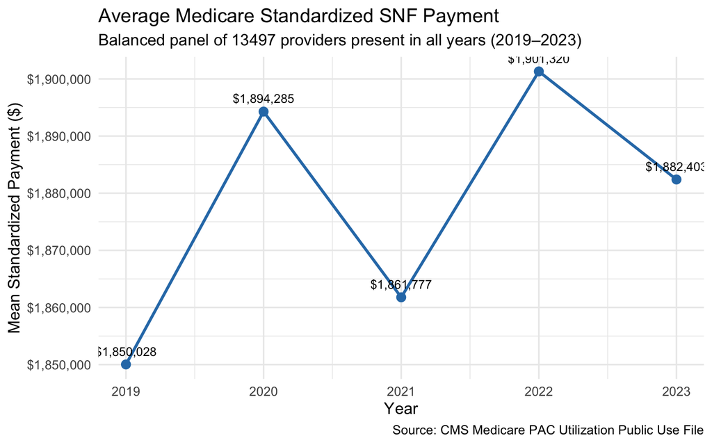

```r
annual_means <- snf_balanced |>
  group_by(year) |>
  summarise(
    mean_payment = round(mean(tot_mdcr_stdzd_pymt_amt, na.rm = TRUE), 2)
  )

ggplot(annual_means, aes(x = year, y = mean_payment)) +
  geom_line(linewidth = 1.1, color = "#2c7bb6") +
  geom_point(size = 3, color = "#2c7bb6") +
  geom_text(aes(label = dollar(mean_payment)),
            vjust = -1, size = 3.5) +
  scale_x_continuous(breaks = 2019:2023) +
  scale_y_continuous(labels = dollar_format()) +
  labs(
    title    = "Average Medicare Standardized SNF Payment",
    subtitle = glue("Balanced panel of {length(ids_all_years)} providers present in all years (2019–2023)"),
    x        = "Year",
    y        = "Mean Standardized Payment ($)",
    caption  = "Source: CMS Medicare PAC Utilization Public Use File"
  ) +
  theme_minimal(base_size = 13)
```

```r
ggsave("outputs/snf_longitudinal_trend.png", width = 10, height = 8)
```

# Write-Up

## Key Findings

The 2023 national sample includes **14161 SNF providers** after filtering to `SMRY_CTGRY == "PROVIDER"`. Mean standardized payment was approximately **$1,846,518**, with a standard deviation of $1,925,772. The mean exceeded the median, indicating a right-skewed distribution in which a relatively small number of providers received considerably higher payments than the typical facility.

State-level averages varied across the country. Since the payment measure is standardized, geographic payment adjustments are largely accounted for, allowing comparisons that are less affected by regional wage differences. Remaining variation may still reflect differences in patient populations, utilization patterns, provider characteristics, and other market factors. However, observed differences should not be interpreted as evidence of better or worse performance. State variation may reflect differences in patient populations, service utilization patterns, provider characteristics, market dynamics, or other unobserved factors not examined in this analysis.

Providers with 50% or more dual-eligible beneficiaries (`bene_dual_pct >= 50`) tend to serve a higher-acuity, lower-income population. Providers serving a larger share of dual-eligible beneficiaries may differ systematically from other providers in terms of patient socioeconomic characteristics, health status, and care needs. Any observed payment differences between these groups should therefore be interpreted as descriptive rather than causal.

## QC Checks Performed

- Raw row counts before and after `SMRY_CTGRY` filter
- Duplicate `PRVDR_ID` check within the 2023 provider subset (none found)
- Missingness check on `TOT_MDCR_STDZD_PYMT_AMT`
- Suppression check via `as.numeric()` coercion
- Scale verification on `bene_dual_pct`
- Per-year unique provider counts before and after balanced-panel restriction
- Confirmed balanced panel row counts are equal across all five years

## Limitations and What I Would Do Differently

**Unweighted means** treat a 10-bed rural SNF identically to a 300-bed urban facility. A weighted mean (weighting by beneficiary count or stay count) would better reflect the average patient experience and is likely what policymakers care about.

**Balanced panel survivor bias**: the 13,497 providers in the longitudinal sample exclude facilities that entered or exited the market over the study period. Stable, longer-operating facilities may differ systematically from newer or recently closed ones, which could bias the trend estimate.

**No risk adjustment**: standardized payments control for geography but not for case mix or patient severity. Differences across states or dual-eligibility groups may reflect underlying patient acuity rather than provider behavior.

**COVID confounding**: the 2020–2021 disruption makes it difficult to interpret the trend as a clean pre-post comparison for any policy change. Separating COVID effects from secular trends would require additional modeling.

To strengthen these conclusions, I would: (1) compute enrollment-weighted means, (2) include an entrant/exit sensitivity analysis for the longitudinal trend, and (3) add a case-mix adjustment using available variables such as `bene_avg_risk_scre`